# Ch2 The Firm and Costs

Jing Fang

# Ch2 The Firm and Costs

- A **firm** is an organization that transforms *inputs* (resources it purchases) into *outputs* (valued products that it sells)
- We start by discussing the objective, organization, and ownership of firms. Next we examine costs.

# Ch2 The Firm and Costs

- The key issues are:
  1. Most firms maximize profits.
  2. Acquisitions and other mergers may force firms to operate efficiently and profitably.
  3. Economists use the concept of an opportunity cost that includes a normal profit.
  4. The cost of a single-product firm depend on the prices of factors of production and the output level.
  5. A multiproduct firm’s cost of producing a single product depends on factor prices, the output level of that product, and the output level of its other products
  6. Production processes may have various properties such as economies of scale and economies of scope.

# The Firm

# The Firm

- Most goods and services produced in Western countries are produced by firms. (84% in US)
- We now examine the objective, organization and ownership of firms.

# The Objective of a Firm

- Most firms are *for-profit* firms: They exist to make money.
- The standard assumption in most economic models is that the primary objective of a manager of a firm is to maximize the firm’s profit, but in fact, they may have other objectives. (max sales, own income)
- Various forces keep manager from deviating from profit-maximizing behavior. (fired, stock/other bonuses)

# Ownership and Control

- *Forms of Ownership*：
  - Sole proprietorships (single owner),
  - Partnerships (multiple owners),
  - Corporations.
- In US, 87% of business sales are made by corporations, even though only 20% of all firms are corporations.

# Ownership and Control

- **Corporations** are companies whose capital is divided into shares that are held by individuals who have only limited responsibility for the debts of the company.
- That is, a shareholder has **limited liability**: If the corporation fail, the stockholders need not pay for the debt using their personal assets.

# Ownership and Control

- A corporation may raise money by selling shares of stock. Shareholders (*equity owner*) are entitled to receive dividend payments, which come out of the corporation’s profit.
- Corporations also raise money by issuing debt. They promise to pay those who lend them money (*debt holders*) a stipulated amount of interest plus repayment of the loan.

# Ownership and Control

- Suppose a corporation raises $1 million by borrowing $500,000 at 20% interest and selling 500,000 shares at $1 each.
- The corporation invests in project, which has an equal chance of succeeding or failing.
  - If the project succeeds, the corporation earns $2 million.
  - If the project fails, the corporation goes out of business and sell its machines for $500,000.

# Ownership and Control

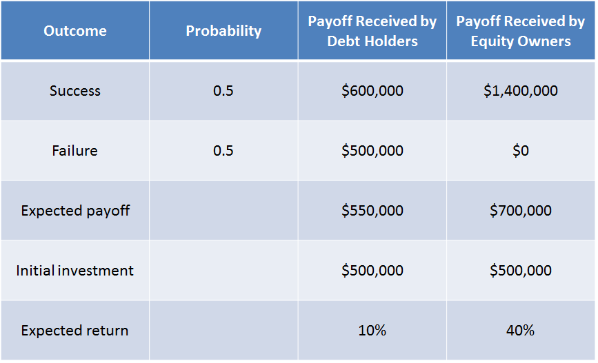

# Separation of Ownership and Control

- When control is separated from ownership, managers may not attempt to maximize profits and may pursue other objectives.
- In many corporations, there is often no single shareholder with the incentive to monitor managers’ actions.
- Shareholders elect a board of directors to do that.
- This control over the board of director and over the managers may be inadequate to ensure profit-maximization behavior.

# Size of Firms

- A firm may expand because it wants to produce more/produce inputs.
- Although a firm may want to grow so as to avoid the cost of doing business with other firms, a larger firm faces higher costs and greater difficulty monitoring its own managers and employees.
- The optimal size of a firm depends on this trade-off.
- Most US firms are small, though larger firms account for most employment and sales. (0.3% firms with >500 employees have >50% employment and >70% sales)

# Mergers and Acquisitions

# Mergers and Acquisitions

- There are three types of mergers:
  - **Vertical merger**: A firm combines with its supplier
  - **Horizontal merger**: Firms that compete within the same market combine
  - **Conglomerate merger**: Firms in unrelated lines of businesses combine.

# Mergers and Acquisitions

- There are many explanations for mergers.
- The main motive is usually to increase profitability.
- Unfortunately, not all mergers result in greater profitability.
- Moreover, some mergers may be profitable for the firm yet harm society by reducing efficiency.

# Cost Concept

# Cost Concept

- A **fixed cost** (F) is an expense that does not vary with the level of output.
- **Variable costs** (VC) are costs that change with the level of output, q.
- **Total costs** (C) are the sum of all fixed and variable cost: C = F + VC
- **Marginal cost** (MC) is the increment, or addition, to cost that results from producing one more unit of output.

# Cost Concept

- **Average cost** (AC) is total cost divided by output: $AC = C(q)/q$
- **Average Variable cost** (AVC) is variable cost divided by output: $AVC = VC(q)/q$
- **Average fixed cost** (AFC) is fixed cost divided by output: $AFC = F/q$
- $AC(q)=\frac{C(q)}{q}=\frac{VC(q)+F}{q}=\frac{VC(q)}{q}+\frac{F}{q}=AVC(q)+AFC(q)$

# Cost Concept

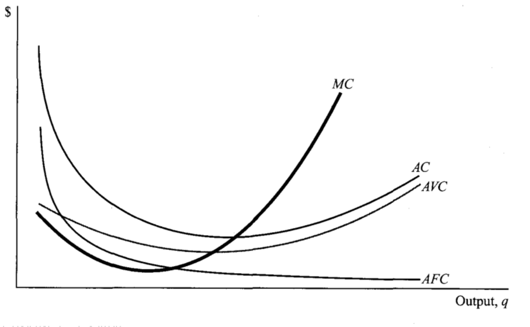

# Cost Concept

- The cost of production depend not only on how much is produced but also on *how fast*.
- The *short run* is a time period so brief that some factors of production cannot be costlessly varied.
- The *long run* is a period of time sufficiently long that all factors of production can be costlessly varied.
- The distinction between short and long run is not precise.

# Cost Concept

- An action’s **opportunity cost** is the value of the best forgone alternative use of the resources employed in that action.
- Surprisingly, if all costs are valued at their opportunity cost, then profit need only be zero to make remaining in business worthwhile.

# Economies of Scale

# Economies of Scale

- If AC falls as output increases, the firm is said to have **economies of scale** (or **increasing return to scale**);
- If AC do not vary with output, it has **constant returns of scale**;
- If AC rises with output, the firm is said to have **diseconomies of scale** (or **decreasing return to scale**).

# Economies of Scale

- There are many reasons to expect a firm’s AC to decline, at least initially, as its output expands.
  - One is that FC do not vary with the level of output.
  - As output expands, a firm can use its labor in more specialized tasks.
  - Certain physical laws generate scale economies.
- Total costs determine scale economies.

# Economies of Scale

- A natural measure of scale economies is the ratio of AC to MC.
- If $s=AC/MC$, then:
  - economies of scale exist if $s>1$
  - constant return to scale exist if $s=1$
  - diseconomies of scale exist if $s<1$

# Cost Concepts for Multiproduct Firms

# Cost Concepts for Multiproduct Firms

- Most firms do not produce a single product. A firm that produces many different products is called a *multiproduct firm*.
- If a firm produces two or more products, one cannot measure the AC or the MC because there is no one measure of output.
- One can, however, define cost concepts that are analogous to those in a single-product environment.

# Cost Concepts for Multiproduct Firms

- TC: $C(q_1,q_2)$
- MC of product i: $\frac{\partial C(q_1,q_2)}{\partial q_i}$
- *Ray average cost* (RAC):
  $$RAC(q)=\frac{C(\lambda_1 q,\lambda_2 q)}{q}$$
  where we have $q_i=\lambda_i q$

# Cost Concepts for Multiproduct Firms

- Proposition: RAC(q) falls, rises, or is constant as q increases, depending on whether s (a measure of scale economy) is above below, or equal to 1, where
  $$s=\frac{C(q)}{q_1\frac{\partial C}{\partial q_1}+q_2\frac{\partial C}{\partial q_2}}$$
- That is, s is the multiproduct analogue of the ratio of AC to MC.

# Cost Concepts for Multiproduct Firms

- Proof:
  $$\begin{array}{rll}
  \frac{dRAC(q)}{dq} & = & \frac{1}{q}[\lambda_1\frac{\partial C}{\partial q_1}+\lambda_2\frac{\partial C}{\partial q_2}]-\frac{1}{q^2}C(q) \\
  & = & \frac{1}{q^2}[\lambda_1 q\frac{\partial C}{\partial q_1}+\lambda_2 q\frac{\partial C}{\partial q_2}-C(q)] \\
  & = & \frac{1}{q^2}[q_1\frac{\partial C}{\partial q_1}+q_2\frac{\partial C}{\partial q_2}-C(q)]
  \end{array}$$

# Cost Concepts for Multiproduct Firms

- In addition to RAC, there are several cost concepts that do not have a clear analogy to the single product case.
- The *incremental costs* of increase product 2 from 0 to q2, holding product 1 constant is:
  $$IC_2=C(q_1,q_2)-C(q_1,0)$$
- The average incremental costs of increasing product 2 from 0 to $q_2$ holding product 1 constant is:
  $$AIC_2=[C(q_1,q_2)-c(q_1,0)]/q_2$$

# Cost Concepts for Multiproduct Firms

- The product specific economies of scale (PS) of qi, holding the other output qj, constant is defined using the AIC:
  $$PS_i=\frac{AIC_i}{MC_i}$$
- PS is the same as the scale measure s, for the particular case where all outputs except qi are held fixed.

# Economies of Scope

- Most firms produce more than one product because it is cheaper to produce them together rather than separately. The term *economy of scope* refers to the savings that result from doing so.
  $$SC=\frac{C(q_1,0)+C(0,q_2)-C(q_1,q_2)}{C(q_1,q_2)}$$
- Many possible factors contribute to economies of scope, and one of the most important is the use of common inputs.

# An Example

- Suppose the cost function is:
  $$C(q_1,q_2)=100+q_1+2q_2$$
- Give the two goods equal weight, that is:
  $$\lambda_1=\lambda_2=0.5$$
- Then, what is:
  - MC,RAC,AIC
  - economies of scale, s; of scope, SC

# An Example

- $MC1=1$, $MC2=2$
- $$\begin{array}{rll}
  C(q_1,q_2) & = & C(\lambda_1 q,\lambda_2 q)=100+0.5q+2\times 0.5q=100+1.5q \\
  RAC(q) & = & \frac{100+1.5q}{q}=\frac{100}{q}+1.5 \\
  AIC(q_1) & = & \frac{100+q_1+2q_2-(100+2q_2)}{q_1}=\frac{q_1}{q_1}=1 \\
  AIC(q_2) & = & \frac{100+q_1+2q_2-(100+q_1)}{q_2}=\frac{2q_2}{q_2}=2
  \end{array}$$

# An Example

- $$s=\frac{C(q_1,q_2)}{q_1\frac{\partial C}{\partial q_1}+q_2\frac{\partial C}{\partial q_2}}=\frac{100+q_1+2q_2}{q_1+2q_2}=\frac{100}{q_1+2q_2}+1$$
- $$\begin{array}{rll}
  SC & = & \frac{C(q_1,0)+C(0,q_2)-C(q_1,q_2)}{C(q_1,q_2)} \\
  & = & \frac{100+q_1+100+2q_2-(100+q_1+2q_2)}{100+q_1+2q_2} \\
  & = & \frac{100}{100+q_1+2q_2}
  \end{array}$$